# Выбор локации для скважины

## Описание проекта

Допустим, вы работаете в добывающей компании «ГлавРосГосНефть». Нужно решить, где бурить новую скважину.

Шаги для выбора локации:

- В избранном регионе ищут месторождения, для каждого определяют значения признаков;
- Строят модель и оценивают объём запасов;
- Выбирают месторождения с самым высокими оценками значений. Количество месторождений зависит от бюджета компании и стоимости разработки одной скважины;
- Прибыль равна суммарной прибыли отобранных месторождений.

## План работы

1. Загрузим и подготовим данные. Поясним порядок действий.
2. Обучим и проверим модель для каждого региона:  
   2.1. Разобъем данные на обучающую и валидационную выборки в соотношении 75:25.  
   2.2. Обучим модель и сделаем предсказания на валидационной выборке.  
   2.3. Сохраним предсказания и правильные ответы на валидационной выборке.  
   2.4. Напечатаем на экране средний запас предсказанного сырья и RMSE модели.  
   2.5. Проанализируем результаты.
3. Подготовимся к расчёту прибыли:  
   3.1. Все ключевые значения для расчётов сохраним в отдельных переменных.  
   3.2. Рассчитаем достаточный объём сырья для безубыточной разработки новой скважины. Сравним полученный объём сырья со средним запасом в каждом регионе.  
   3.3. Напишем выводы по этапу подготовки расчёта прибыли.
4. Напишем функцию для расчёта прибыли по выбранным скважинам и предсказаниям модели:  
   4.1. Выберем скважины с максимальными значениями предсказаний.  
   4.2. Просуммируем целевое значение объёма сырья, соответствующее этим предсказаниям.  
   4.3. Рассчитаем прибыль для полученного объёма сырья.
5. Посчитаем риски и прибыль для каждого региона:  
   5.1. Применим технику Bootstrap с 1000 выборок, чтобы найти распределение прибыли.  
   5.2. Найдем среднюю прибыль, 95%-й доверительный интервал и риск убытков. Убыток — это отрицательная прибыль.  
   5.3. Напишем выводы: предложим регион для разработки скважин и обоснуем выбор.

## Описание данных

- `id` — уникальный идентификатор скважины
- `f0`, `f1`, `f2` — три признака точек (неважно, что они означают, но сами признаки значимы)
- `product` — объём запасов в скважине (тыс. баррелей)

*Данные геологоразведки трёх регионов находятся в файлах:*

- `/datasets/geo_data_0.csv`
- `/datasets/geo_data_1.csv`
- `/datasets/geo_data_2.csv`

## Условия задачи

- Для обучения модели подходит только линейная регрессия (остальные — недостаточно предсказуемые)
- При разведке региона исследуют 500 точек, из которых с помощью машинного обучения выбирают 200 лучших для разработки
- Бюджет на разработку скважин в регионе — 10 млрд рублей
- При нынешних ценах один баррель сырья приносит 450 рублей дохода. Доход с каждой единицы продукта составляет 450 тыс. рублей, поскольку объём указан в тысячах баррелей
- После оценки рисков нужно оставить лишь те регионы, в которых вероятность убытков меньше 2.5%. Среди них выбирают регион с наибольшей средней прибылью

*Данные синтетические: детали контрактов и характеристики месторождений не разглашаются.*

```python
from IPython.core.display import display, HTML
display(HTML("<style>.container { width:90% !important; }</style>"))
```

```python
import warnings
warnings.filterwarnings('ignore')
```

## Загрузка и подготовка данных

```python
!pip install phik
```

```python
import pandas as pd
from sklearn.linear_model import LinearRegression
import numpy as np
import matplotlib.pyplot as plt
import itertools
import seaborn as sns
from sklearn.metrics import mean_squared_error
from sklearn.model_selection import train_test_split
from sklearn.neighbors import KNeighborsClassifier
from sklearn.preprocessing import StandardScaler, PolynomialFeatures
import phik
from numpy.random import RandomState
```

```python
geo_data_0 = pd.read_csv('/datasets/geo_data_0.csv')
geo_data_0.head(10)
```

|  | id | f0 | f1 | f2 | product |
| --- | --- | --- | --- | --- | --- |
| 0 | txEyH | 0.705745 | -0.497823 | 1.221170 | 105.280062 |
| 1 | 2acmU | 1.334711 | -0.340164 | 4.365080 | 73.037750 |
| 2 | 409Wp | 1.022732 | 0.151990 | 1.419926 | 85.265647 |
| 3 | iJLyR | -0.032172 | 0.139033 | 2.978566 | 168.620776 |
| 4 | Xdl7t | 1.988431 | 0.155413 | 4.751769 | 154.036647 |
| 5 | wX4Hy | 0.969570 | 0.489775 | -0.735383 | 64.741541 |
| 6 | tL6pL | 0.645075 | 0.530656 | 1.780266 | 49.055285 |
| 7 | BYPU6 | -0.400648 | 0.808337 | -5.624670 | 72.943292 |
| 8 | j9Oui | 0.643105 | -0.551583 | 2.372141 | 113.356160 |
| 9 | OLuZU | 2.173381 | 0.563698 | 9.441852 | 127.910945 |

```python
geo_data_1 = pd.read_csv('/datasets/geo_data_1.csv')
geo_data_1.head(10)
```

|  | id | f0 | f1 | f2 | product |
| --- | --- | --- | --- | --- | --- |
| 0 | kBEdx | -15.001348 | -8.276000 | -0.005876 | 3.179103 |
| 1 | 62mP7 | 14.272088 | -3.475083 | 0.999183 | 26.953261 |
| 2 | vyE1P | 6.263187 | -5.948386 | 5.001160 | 134.766305 |
| 3 | KcrkZ | -13.081196 | -11.506057 | 4.999415 | 137.945408 |
| 4 | AHL4O | 12.702195 | -8.147433 | 5.004363 | 134.766305 |
| 5 | HHckp | -3.327590 | -2.205276 | 3.003647 | 84.038886 |
| 6 | h5Ujo | -11.142655 | -10.133399 | 4.002382 | 110.992147 |
| 7 | muH9x | 4.234715 | -0.001354 | 2.004588 | 53.906522 |
| 8 | YiRkx | 13.355129 | -0.332068 | 4.998647 | 134.766305 |
| 9 | jG6Gi | 1.069227 | -11.025667 | 4.997844 | 137.945408 |

```python
geo_data_2 = pd.read_csv('/datasets/geo_data_2.csv')
geo_data_2.head(10)
```

|  | id | f0 | f1 | f2 | product |
| --- | --- | --- | --- | --- | --- |
| 0 | fwXo0 | -1.146987 | 0.963328 | -0.828965 | 27.758673 |
| 1 | WJtFt | 0.262778 | 0.269839 | -2.530187 | 56.069697 |
| 2 | ovLUW | 0.194587 | 0.289035 | -5.586433 | 62.871910 |
| 3 | q6cA6 | 2.236060 | -0.553760 | 0.930038 | 114.572842 |
| 4 | WPMUX | -0.515993 | 1.716266 | 5.899011 | 149.600746 |
| 5 | LzZXx | -0.758092 | 0.710691 | 2.585887 | 90.222465 |
| 6 | WBHRv | -0.574891 | 0.317727 | 1.773745 | 45.641478 |
| 7 | XO8fn | -1.906649 | -2.458350 | -0.177097 | 72.480640 |
| 8 | ybmQ5 | 1.776292 | -0.279356 | 3.004156 | 106.616832 |
| 9 | OilcN | -1.214452 | -0.439314 | 5.922514 | 52.954532 |

```python
geo_data_0.info()
```

```
<class 'pandas.core.frame.DataFrame'>
RangeIndex: 100000 entries, 0 to 99999
Data columns (total 5 columns):
 #   Column   Non-Null Count   Dtype
---  ------   --------------   -----
 0   id       100000 non-null  object
 1   f0       100000 non-null  float64
 2   f1       100000 non-null  float64
 3   f2       100000 non-null  float64
 4   product  100000 non-null  float64
dtypes: float64(4), object(1)
memory usage: 3.8+ MB
```

```python
geo_data_0.describe()
```

|  | f0 | f1 | f2 | product |
| --- | --- | --- | --- | --- |
| count | 100000.000000 | 100000.000000 | 100000.000000 | 100000.000000 |
| mean | 0.500419 | 0.250143 | 2.502647 | 92.500000 |
| std | 0.871832 | 0.504433 | 3.248248 | 44.288691 |
| min | -1.408605 | -0.848218 | -12.088328 | 0.000000 |
| 25% | -0.072580 | -0.200881 | 0.287748 | 56.497507 |
| 50% | 0.502360 | 0.250252 | 2.515969 | 91.849972 |
| 75% | 1.073581 | 0.700646 | 4.715088 | 128.564089 |
| max | 2.362331 | 1.343769 | 16.003790 | 185.364347 |

```python
geo_data_0.isna().sum()
```

```
id         0
f0         0
f1         0
f2         0
product    0
dtype: int64
```

```python
geo_data_0.duplicated().sum()
```

```
0
```

```python
duplicate_id = geo_data_0[geo_data_0.duplicated(['id'])]
id_duplicate = duplicate_id['id'].unique()
geo_data_0.loc[geo_data_0['id'].isin(id_duplicate)].sort_values(by = 'id', ascending = False)
```

|  | id | f0 | f1 | f2 | product |
| --- | --- | --- | --- | --- | --- |
| 90815 | fiKDv | 0.049883 | 0.841313 | 6.394613 | 137.346586 |
| 16633 | fiKDv | 0.157341 | 1.028359 | 5.585586 | 95.817889 |
| 41724 | bxg6G | -0.823752 | 0.546319 | 3.630479 | 93.007798 |
| 1364 | bxg6G | 0.411645 | 0.856830 | -3.653440 | 73.604260 |
| 97785 | bsk9y | 0.378429 | 0.005837 | 0.160827 | 160.637302 |
| 89582 | bsk9y | 0.398908 | -0.400253 | 10.122376 | 163.433078 |
| 92341 | TtcGQ | 0.110711 | 1.022689 | 0.911381 | 101.318008 |
| 60140 | TtcGQ | 0.569276 | -0.104876 | 6.440215 | 85.350186 |
| 21426 | Tdehs | 0.829407 | 0.298807 | -0.049563 | 96.035308 |
| 75715 | Tdehs | 0.112079 | 0.430296 | 3.218993 | 60.964018 |
| 63593 | QcMuo | 0.635635 | -0.473422 | 0.862670 | 64.578675 |
| 1949 | QcMuo | 0.506563 | -0.323775 | -2.215583 | 75.496502 |
| 7530 | HZww2 | 1.061194 | -0.373969 | 10.430210 | 158.828695 |
| 931 | HZww2 | 0.755284 | 0.368511 | 1.863211 | 30.681774 |
| 42529 | AGS9W | 1.454747 | -0.479651 | 0.683380 | 126.370504 |
| 69163 | AGS9W | -0.933795 | 0.116194 | -3.655896 | 19.230453 |
| 51970 | A5aEY | -0.180335 | 0.935548 | -2.094773 | 33.020205 |
| 3389 | A5aEY | -0.039949 | 0.156872 | 0.209861 | 89.249364 |
| 64022 | 74z30 | 0.741456 | 0.459229 | 5.153109 | 140.771492 |
| 66136 | 74z30 | 1.084962 | -0.312358 | 6.990771 | 127.643327 |

*Данные геологоразведки из файла `/datasets/geo_data_0.csv` загружены. Пропусков и дубликатов нет. Обнаружены дубликаты парные `id` уникального идентификатора скважины. Остальные данные по данным скважинам различные, что свидетельстует об информации по отдельным различным скважинам. Будем дообозначать дублирующие идентификаторы скважин значением `_1` и `_2`.*

```python
id_duplicate_index = geo_data_0.loc[geo_data_0['id'].isin(id_duplicate)].sort_values(by = 'id', ascending = False).index
print(id_duplicate_index)

honest = geo_data_0[geo_data_0.duplicated(['id'])].sort_values(by = 'id', ascending = False).index
print(honest)

odd = geo_data_0.loc[geo_data_0['id'].isin(id_duplicate)].drop(index=honest).sort_values(by = 'id', ascending = False).index
print(odd)
```

```
Int64Index([90815, 16633, 41724,  1364, 97785, 89582, 92341, 60140, 21426,
            75715, 63593,  1949,  7530,   931, 42529, 69163, 51970,  3389,
            64022, 66136],
           dtype='int64')
Int64Index([90815, 41724, 97785, 92341, 75715, 63593, 7530, 69163, 51970,
            66136],
           dtype='int64')
Int64Index([16633, 1364, 89582, 60140, 21426, 1949, 931, 42529, 3389, 64022], dtype='int64')
```

```python
honest_df = geo_data_0.loc[honest]
display(honest_df.sort_values(by = 'id', ascending = False))
odd_df = geo_data_0.loc[odd]
display(odd_df.sort_values(by = 'id', ascending = False))
geo_data_0 = geo_data_0.drop(index=id_duplicate_index)
geo_data_0.info()
```

|  | id | f0 | f1 | f2 | product |
| --- | --- | --- | --- | --- | --- |
| 90815 | fiKDv | 0.049883 | 0.841313 | 6.394613 | 137.346586 |
| 41724 | bxg6G | -0.823752 | 0.546319 | 3.630479 | 93.007798 |
| 97785 | bsk9y | 0.378429 | 0.005837 | 0.160827 | 160.637302 |
| 92341 | TtcGQ | 0.110711 | 1.022689 | 0.911381 | 101.318008 |
| 75715 | Tdehs | 0.112079 | 0.430296 | 3.218993 | 60.964018 |
| 63593 | QcMuo | 0.635635 | -0.473422 | 0.862670 | 64.578675 |
| 7530 | HZww2 | 1.061194 | -0.373969 | 10.430210 | 158.828695 |
| 69163 | AGS9W | -0.933795 | 0.116194 | -3.655896 | 19.230453 |
| 51970 | A5aEY | -0.180335 | 0.935548 | -2.094773 | 33.020205 |
| 66136 | 74z30 | 1.084962 | -0.312358 | 6.990771 | 127.643327 |

|  | id | f0 | f1 | f2 | product |
| --- | --- | --- | --- | --- | --- |
| 16633 | fiKDv | 0.157341 | 1.028359 | 5.585586 | 95.817889 |
| 1364 | bxg6G | 0.411645 | 0.856830 | -3.653440 | 73.604260 |
| 89582 | bsk9y | 0.398908 | -0.400253 | 10.122376 | 163.433078 |
| 60140 | TtcGQ | 0.569276 | -0.104876 | 6.440215 | 85.350186 |
| 21426 | Tdehs | 0.829407 | 0.298807 | -0.049563 | 96.035308 |
| 1949 | QcMuo | 0.506563 | -0.323775 | -2.215583 | 75.496502 |
| 931 | HZww2 | 0.755284 | 0.368511 | 1.863211 | 30.681774 |
| 42529 | AGS9W | 1.454747 | -0.479651 | 0.683380 | 126.370504 |
| 3389 | A5aEY | -0.039949 | 0.156872 | 0.209861 | 89.249364 |
| 64022 | 74z30 | 0.741456 | 0.459229 | 5.153109 | 140.771492 |

```
<class 'pandas.core.frame.DataFrame'>
Int64Index: 99980 entries, 0 to 99999
Data columns (total 5 columns):
 #   Column   Non-Null Count  Dtype
---  ------   --------------  -----
 0   id       99980 non-null  object
 1   f0       99980 non-null  float64
 2   f1       99980 non-null  float64
 3   f2       99980 non-null  float64
 4   product  99980 non-null  float64
dtypes: float64(4), object(1)
memory usage: 4.6+ MB
```

```python
honest_df['id'] = honest_df['id'].astype(str).apply(lambda col: col + '_1')
display(honest_df.sort_values(by = 'id', ascending = False))
```

|  | id | f0 | f1 | f2 | product |
| --- | --- | --- | --- | --- | --- |
| 90815 | fiKDv_1 | 0.049883 | 0.841313 | 6.394613 | 137.346586 |
| 41724 | bxg6G_1 | -0.823752 | 0.546319 | 3.630479 | 93.007798 |
| 97785 | bsk9y_1 | 0.378429 | 0.005837 | 0.160827 | 160.637302 |
| 92341 | TtcGQ_1 | 0.110711 | 1.022689 | 0.911381 | 101.318008 |
| 75715 | Tdehs_1 | 0.112079 | 0.430296 | 3.218993 | 60.964018 |
| 63593 | QcMuo_1 | 0.635635 | -0.473422 | 0.862670 | 64.578675 |
| 7530 | HZww2_1 | 1.061194 | -0.373969 | 10.430210 | 158.828695 |
| 69163 | AGS9W_1 | -0.933795 | 0.116194 | -3.655896 | 19.230453 |
| 51970 | A5aEY_1 | -0.180335 | 0.935548 | -2.094773 | 33.020205 |
| 66136 | 74z30_1 | 1.084962 | -0.312358 | 6.990771 | 127.643327 |

```python
odd_df['id'] = odd_df['id'].astype(str).apply(lambda col: col + '_2')
display(odd_df.sort_values(by = 'id', ascending = False))
```

|  | id | f0 | f1 | f2 | product |
| --- | --- | --- | --- | --- | --- |
| 16633 | fiKDv_2 | 0.157341 | 1.028359 | 5.585586 | 95.817889 |
| 1364 | bxg6G_2 | 0.411645 | 0.856830 | -3.653440 | 73.604260 |
| 89582 | bsk9y_2 | 0.398908 | -0.400253 | 10.122376 | 163.433078 |
| 60140 | TtcGQ_2 | 0.569276 | -0.104876 | 6.440215 | 85.350186 |
| 21426 | Tdehs_2 | 0.829407 | 0.298807 | -0.049563 | 96.035308 |
| 1949 | QcMuo_2 | 0.506563 | -0.323775 | -2.215583 | 75.496502 |
| 931 | HZww2_2 | 0.755284 | 0.368511 | 1.863211 | 30.681774 |
| 42529 | AGS9W_2 | 1.454747 | -0.479651 | 0.683380 | 126.370504 |
| 3389 | A5aEY_2 | -0.039949 | 0.156872 | 0.209861 | 89.249364 |
| 64022 | 74z30_2 | 0.741456 | 0.459229 | 5.153109 | 140.771492 |

```python
geo_data_0 = pd.concat([geo_data_0,honest_df, odd_df], ignore_index= True )
geo_data_0.info()
```

```
<class 'pandas.core.frame.DataFrame'>
RangeIndex: 100000 entries, 0 to 99999
Data columns (total 5 columns):
 #   Column   Non-Null Count   Dtype
---  ------   --------------   -----
 0   id       100000 non-null  object
 1   f0       100000 non-null  float64
 2   f1       100000 non-null  float64
 3   f2       100000 non-null  float64
 4   product  100000 non-null  float64
dtypes: float64(4), object(1)
memory usage: 3.8+ MB
```

```python
geo_data_0.duplicated(['id']).sum()
```

```
0
```

*Данные из файла `/datasets/geo_data_0.csv` обработаны. Дубликаты `id` уникального идентификатора скважины отсутствуют.*

```python
geo_data_1.info()
```

```
<class 'pandas.core.frame.DataFrame'>
RangeIndex: 100000 entries, 0 to 99999
Data columns (total 5 columns):
 #   Column   Non-Null Count   Dtype
---  ------   --------------   -----
 0   id       100000 non-null  object
 1   f0       100000 non-null  float64
 2   f1       100000 non-null  float64
 3   f2       100000 non-null  float64
 4   product  100000 non-null  float64
dtypes: float64(4), object(1)
memory usage: 3.8+ MB
```

```python
geo_data_1.describe()
```

|  | f0 | f1 | f2 | product |
| --- | --- | --- | --- | --- |
| count | 100000.000000 | 100000.000000 | 100000.000000 | 100000.000000 |
| mean | 1.141296 | -4.796579 | 2.494541 | 68.825000 |
| std | 8.965932 | 5.119872 | 1.703572 | 45.944423 |
| min | -31.609576 | -26.358598 | -0.018144 | 0.000000 |
| 25% | -6.298551 | -8.267985 | 1.000021 | 26.953261 |
| 50% | 1.153055 | -4.813172 | 2.011479 | 57.085625 |
| 75% | 8.621015 | -1.332816 | 3.999904 | 107.813044 |
| max | 29.421755 | 18.734063 | 5.019721 | 137.945408 |

```python
geo_data_1.isna().sum()
```

```
id         0
f0         0
f1         0
f2         0
product    0
dtype: int64
```

```python
geo_data_1.duplicated().sum()
```

```
0
```

```python
duplicate_id = geo_data_1[geo_data_1.duplicated(['id'])]
id_duplicate = duplicate_id['id'].unique()
geo_data_1.loc[geo_data_1['id'].isin(id_duplicate)].sort_values(by = 'id', ascending = False)
```

|  | id | f0 | f1 | f2 | product |
| --- | --- | --- | --- | --- | --- |
| 47591 | wt4Uk | -9.091098 | -8.109279 | -0.002314 | 3.179103 |
| 82873 | wt4Uk | 10.259972 | -9.376355 | 4.994297 | 134.766305 |
| 2721 | bfPNe | -9.494442 | -5.463692 | 4.006042 | 110.992147 |
| 82178 | bfPNe | -6.202799 | -4.820045 | 2.995107 | 84.038886 |
| 1305 | LHZR0 | 11.170835 | -1.945066 | 3.002872 | 80.859783 |
| 41906 | LHZR0 | -8.989672 | -4.286607 | 2.009139 | 57.085625 |
| 5849 | 5ltQ6 | -3.435401 | -12.296043 | 1.999796 | 57.085625 |
| 84461 | 5ltQ6 | 18.213839 | 2.191999 | 3.993869 | 107.813044 |

*Данные геологоразведки из файла `/datasets/geo_data_1.csv` загружены. Пропусков и дубликатов нет. Обнаружены дубликаты парные `id` уникального идентификатора скважины. Остальные данные по данным скважинам различные, что свидетельстует об информации по отдельным различным скважинам. Будем дообозначать дублирующие идентификаторы скважин значением `_1` и `_2`.*

```python
id_duplicate_index = geo_data_1.loc[geo_data_1['id'].isin(id_duplicate)].sort_values(by = 'id', ascending = False).index
print(id_duplicate_index)

honest = geo_data_1[geo_data_1.duplicated(['id'])].sort_values(by = 'id', ascending = False).index
print(honest)

odd = geo_data_1.loc[geo_data_1['id'].isin(id_duplicate)].drop(index=honest).sort_values(by = 'id', ascending = False).index
print(odd)
```

```
Int64Index([47591, 82873, 2721, 82178, 1305, 41906, 5849, 84461], dtype='int64')
Int64Index([82873, 82178, 41906, 84461], dtype='int64')
Int64Index([47591, 2721, 1305, 5849], dtype='int64')
```

```python
honest_df = geo_data_1.loc[honest]
display(honest_df.sort_values(by = 'id', ascending = False))
odd_df = geo_data_1.loc[odd]
display(odd_df.sort_values(by = 'id', ascending = False))
geo_data_1 = geo_data_1.drop(index=id_duplicate_index)
geo_data_1.info()
```

|  | id | f0 | f1 | f2 | product |
| --- | --- | --- | --- | --- | --- |
| 82873 | wt4Uk | 10.259972 | -9.376355 | 4.994297 | 134.766305 |
| 82178 | bfPNe | -6.202799 | -4.820045 | 2.995107 | 84.038886 |
| 41906 | LHZR0 | -8.989672 | -4.286607 | 2.009139 | 57.085625 |
| 84461 | 5ltQ6 | 18.213839 | 2.191999 | 3.993869 | 107.813044 |

|  | id | f0 | f1 | f2 | product |
| --- | --- | --- | --- | --- | --- |
| 47591 | wt4Uk | -9.091098 | -8.109279 | -0.002314 | 3.179103 |
| 2721 | bfPNe | -9.494442 | -5.463692 | 4.006042 | 110.992147 |
| 1305 | LHZR0 | 11.170835 | -1.945066 | 3.002872 | 80.859783 |
| 5849 | 5ltQ6 | -3.435401 | -12.296043 | 1.999796 | 57.085625 |

```
<class 'pandas.core.frame.DataFrame'>
Int64Index: 99992 entries, 0 to 99999
Data columns (total 5 columns):
 #   Column   Non-Null Count  Dtype
---  ------   --------------  -----
 0   id       99992 non-null  object
 1   f0       99992 non-null  float64
 2   f1       99992 non-null  float64
 3   f2       99992 non-null  float64
 4   product  99992 non-null  float64
dtypes: float64(4), object(1)
memory usage: 4.6+ MB
```

```python
honest_df['id'] = honest_df['id'].astype(str).apply(lambda col: col + '_1')
display(honest_df.sort_values(by = 'id', ascending = False))
```

|  | id | f0 | f1 | f2 | product |
| --- | --- | --- | --- | --- | --- |
| 82873 | wt4Uk_1 | 10.259972 | -9.376355 | 4.994297 | 134.766305 |
| 82178 | bfPNe_1 | -6.202799 | -4.820045 | 2.995107 | 84.038886 |
| 41906 | LHZR0_1 | -8.989672 | -4.286607 | 2.009139 | 57.085625 |
| 84461 | 5ltQ6_1 | 18.213839 | 2.191999 | 3.993869 | 107.813044 |

```python
odd_df['id'] = odd_df['id'].astype(str).apply(lambda col: col + '_2')
display(odd_df.sort_values(by = 'id', ascending = False))
```

|  | id | f0 | f1 | f2 | product |
| --- | --- | --- | --- | --- | --- |
| 47591 | wt4Uk_2 | -9.091098 | -8.109279 | -0.002314 | 3.179103 |
| 2721 | bfPNe_2 | -9.494442 | -5.463692 | 4.006042 | 110.992147 |
| 1305 | LHZR0_2 | 11.170835 | -1.945066 | 3.002872 | 80.859783 |
| 5849 | 5ltQ6_2 | -3.435401 | -12.296043 | 1.999796 | 57.085625 |

```python
geo_data_1 = pd.concat([geo_data_1,honest_df, odd_df], ignore_index= True )
geo_data_1.info()
```

```
<class 'pandas.core.frame.DataFrame'>
RangeIndex: 100000 entries, 0 to 99999
Data columns (total 5 columns):
 #   Column   Non-Null Count   Dtype
---  ------   --------------   -----
 0   id       100000 non-null  object
 1   f0       100000 non-null  float64
 2   f1       100000 non-null  float64
 3   f2       100000 non-null  float64
 4   product  100000 non-null  float64
dtypes: float64(4), object(1)
memory usage: 3.8+ MB
```

```python
geo_data_1.duplicated(['id']).sum()
```

```
0
```

*Данные из файла `/datasets/geo_data_1.csv` обработаны. Дубликаты `id` уникального идентификатора скважины отсутствуют.*

```python
geo_data_2.info()
```

```
<class 'pandas.core.frame.DataFrame'>
RangeIndex: 100000 entries, 0 to 99999
Data columns (total 5 columns):
 #   Column   Non-Null Count   Dtype
---  ------   --------------   -----
 0   id       100000 non-null  object
 1   f0       100000 non-null  float64
 2   f1       100000 non-null  float64
 3   f2       100000 non-null  float64
 4   product  100000 non-null  float64
dtypes: float64(4), object(1)
memory usage: 3.8+ MB
```

```python
geo_data_2.describe()
```

|  | f0 | f1 | f2 | product |
| --- | --- | --- | --- | --- |
| count | 100000.000000 | 100000.000000 | 100000.000000 | 100000.000000 |
| mean | 0.002023 | -0.002081 | 2.495128 | 95.000000 |
| std | 1.732045 | 1.730417 | 3.473445 | 44.749921 |
| min | -8.760004 | -7.084020 | -11.970335 | 0.000000 |
| 25% | -1.162288 | -1.174820 | 0.130359 | 59.450441 |
| 50% | 0.009424 | -0.009482 | 2.484236 | 94.925613 |
| 75% | 1.158535 | 1.163678 | 4.858794 | 130.595027 |
| max | 7.238262 | 7.844801 | 16.739402 | 190.029838 |

```python
geo_data_2.isna().sum()
```

```
id         0
f0         0
f1         0
f2         0
product    0
dtype: int64
```

```python
geo_data_2.duplicated().sum()
```

```
0
```

```python
duplicate_id = geo_data_2[geo_data_2.duplicated(['id'])]
id_duplicate = duplicate_id['id'].unique()
geo_data_2.loc[geo_data_2['id'].isin(id_duplicate)].sort_values(by = 'id', ascending = False)
```

|  | id | f0 | f1 | f2 | product |
| --- | --- | --- | --- | --- | --- |
| 28039 | xCHr8 | 1.633027 | 0.368135 | -2.378367 | 6.120525 |
| 43233 | xCHr8 | -0.847066 | 2.101796 | 5.597130 | 184.388641 |
| 44378 | Vcm5J | -1.229484 | -2.439204 | 1.222909 | 137.968290 |
| 95090 | Vcm5J | 2.587702 | 1.986875 | 2.482245 | 92.327572 |
| 11449 | VF7Jo | 2.122656 | -0.858275 | 5.746001 | 181.716817 |
| 49564 | VF7Jo | -0.883115 | 0.560537 | 0.723601 | 136.233420 |
| 45404 | KUPhW | 0.231846 | -1.698941 | 4.990775 | 11.716299 |
| 55967 | KUPhW | 1.211150 | 3.176408 | 5.543540 | 132.831802 |

*Данные геологоразведки из файла `/datasets/geo_data_2.csv` загружены. Пропусков и дубликатов нет. Обнаружены дубликаты парные `id` уникального идентификатора скважины. Остальные данные по данным скважинам различные, что свидетельстует об информации по отдельным различным скважинам. Будем дообозначать дублирующие идентификаторы скважинн значением `_1` и `_2`.*

```python
id_duplicate_index = geo_data_2.loc[geo_data_2['id'].isin(id_duplicate)].sort_values(by = 'id', ascending = False).index
print(id_duplicate_index)

honest = geo_data_0[geo_data_2.duplicated(['id'])].sort_values(by = 'id', ascending = False).index
print(honest)

odd = geo_data_2.loc[geo_data_2['id'].isin(id_duplicate)].drop(index=honest).sort_values(by = 'id', ascending = False).index
print(odd)
```

```
Int64Index([28039, 43233, 44378, 95090, 11449, 49564, 45404, 55967], dtype='int64')
Int64Index([95090, 43233, 55967, 49564], dtype='int64')
Int64Index([28039, 44378, 11449, 45404], dtype='int64')
```

```python
honest_df = geo_data_2.loc[honest]
display(honest_df.sort_values(by = 'id', ascending = False))
odd_df = geo_data_2.loc[odd]
display(odd_df.sort_values(by = 'id', ascending = False))
geo_data_2 = geo_data_2.drop(index=id_duplicate_index)
geo_data_2.info()
```

|  | id | f0 | f1 | f2 | product |
| --- | --- | --- | --- | --- | --- |
| 43233 | xCHr8 | -0.847066 | 2.101796 | 5.597130 | 184.388641 |
| 95090 | Vcm5J | 2.587702 | 1.986875 | 2.482245 | 92.327572 |
| 49564 | VF7Jo | -0.883115 | 0.560537 | 0.723601 | 136.233420 |
| 55967 | KUPhW | 1.211150 | 3.176408 | 5.543540 | 132.831802 |

|  | id | f0 | f1 | f2 | product |
| --- | --- | --- | --- | --- | --- |
| 28039 | xCHr8 | 1.633027 | 0.368135 | -2.378367 | 6.120525 |
| 44378 | Vcm5J | -1.229484 | -2.439204 | 1.222909 | 137.968290 |
| 11449 | VF7Jo | 2.122656 | -0.858275 | 5.746001 | 181.716817 |
| 45404 | KUPhW | 0.231846 | -1.698941 | 4.990775 | 11.716299 |

```
<class 'pandas.core.frame.DataFrame'>
Int64Index: 99992 entries, 0 to 99999
Data columns (total 5 columns):
 #   Column   Non-Null Count  Dtype
---  ------   --------------  -----
 0   id       99992 non-null  object
 1   f0       99992 non-null  float64
 2   f1       99992 non-null  float64
 3   f2       99992 non-null  float64
 4   product  99992 non-null  float64
dtypes: float64(4), object(1)
memory usage: 4.6+ MB
```

```python
honest_df['id'] = honest_df['id'].astype(str).apply(lambda col: col + '_1')
display(honest_df.sort_values(by = 'id', ascending = False))
```

|  | id | f0 | f1 | f2 | product |
| --- | --- | --- | --- | --- | --- |
| 43233 | xCHr8_1 | -0.847066 | 2.101796 | 5.597130 | 184.388641 |
| 95090 | Vcm5J_1 | 2.587702 | 1.986875 | 2.482245 | 92.327572 |
| 49564 | VF7Jo_1 | -0.883115 | 0.560537 | 0.723601 | 136.233420 |
| 55967 | KUPhW_1 | 1.211150 | 3.176408 | 5.543540 | 132.831802 |

```python
odd_df['id'] = odd_df['id'].astype(str).apply(lambda col: col + '_2')
display(odd_df.sort_values(by = 'id', ascending = False))
```

|  | id | f0 | f1 | f2 | product |
| --- | --- | --- | --- | --- | --- |
| 28039 | xCHr8_2 | 1.633027 | 0.368135 | -2.378367 | 6.120525 |
| 44378 | Vcm5J_2 | -1.229484 | -2.439204 | 1.222909 | 137.968290 |
| 11449 | VF7Jo_2 | 2.122656 | -0.858275 | 5.746001 | 181.716817 |
| 45404 | KUPhW_2 | 0.231846 | -1.698941 | 4.990775 | 11.716299 |

```python
geo_data_2 = pd.concat([geo_data_2,honest_df, odd_df], ignore_index= True )
geo_data_2.info()
```

```
<class 'pandas.core.frame.DataFrame'>
RangeIndex: 100000 entries, 0 to 99999
Data columns (total 5 columns):
 #   Column   Non-Null Count   Dtype
---  ------   --------------   -----
 0   id       100000 non-null  object
 1   f0       100000 non-null  float64
 2   f1       100000 non-null  float64
 3   f2       100000 non-null  float64
 4   product  100000 non-null  float64
dtypes: float64(4), object(1)
memory usage: 3.8+ MB
```

```python
geo_data_2.duplicated(['id']).sum()
```

```
0
```

*Данные из файла `/datasets/geo_data_2.csv` обработаны. Дубликаты `id` уникального идентификатора скважины отсутствуют.*

*Построим диаграммы размаха и проанализируем полученные данные.*

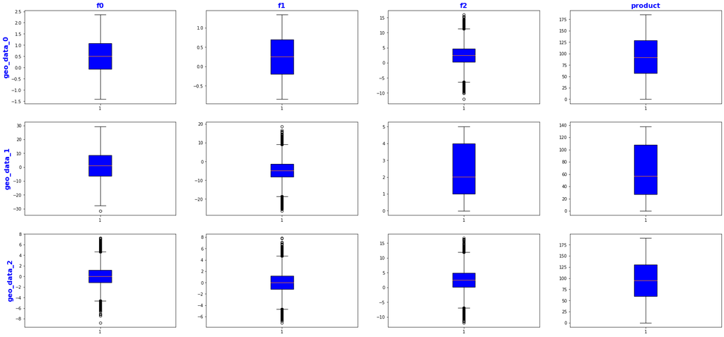

```python
fig,ax = plt.subplots(3,4,figsize = (30,14))

all_data = ['geo_data_0','geo_data_1','geo_data_2']
num_column = geo_data_0.columns[1:]
num_columns = zip(geo_data_0.columns[1:],range(4))
all_data_rows = zip([geo_data_0,geo_data_1,geo_data_2],range(3))

for column in list(itertools.product(all_data_rows,num_columns)):
    ax[column[0][1]][column[1][1]].boxplot(column[0][0][column[1][0]], patch_artist = True, boxprops = dict(facecolor = "blue"))

for row in range(3):
    ax[row][0].set_ylabel(all_data[row], fontsize=16, fontweight="bold", color='blue')

for column in range(4):
    ax[0][column].set_title(num_column[column], fontsize=16, fontweight="bold", color='blue')
```

*Наблюдаем на 6 графиках выбросы за нижним и верхним кварти́лем: `geo_data_0, f2` , `geo_data_1, f0` , `geo_data_1, f1` , `geo_data_2, f0` , `geo_data_2, f1` , `geo_data_2, f2`. Посчитаем процент этих выбросов и, при необходимости, удалим их.*

```python
emissions_data = [(geo_data_0,'f2', 'geo_data_0'), (geo_data_1,'f0', 'geo_data_1'),
                  (geo_data_1,'f1', 'geo_data_1'), (geo_data_2,'f0', 'geo_data_2'), (geo_data_2,'f1', 'geo_data_2'), (geo_data_2,'f2', 'geo_data_2')]
```

```python
def percent_del_index(data, column, name):
    dfs = name
    q25=np.array(data[column].quantile(0.25))

    q75=np.array(data[column].quantile(0.75))
    first_part=q25-1.5*(q75-q25)
    second_part=q75+1.5*(q75-q25)
    data_del_index = []
    for index_value, value in zip(data[column].index,data[column]):
        if second_part <= value or value <= first_part:
            data_del_index.append(index_value)
    percent_del_index = len(data_del_index)*100/len(data)
    print('\u001b[38;5;19m','Процент строк в файле', dfs, 'и признаке', column, 'выбранных для удаления:', percent_del_index,'%', '\u001b[0m')
    return percent_del_index
```

```python
for data, column, name in emissions_data:
    percent_del_index(data,column,name)
```

```
 Процент строк в файле geo_data_0 и признаке f2 выбранных для удаления: 0.506 %
 Процент строк в файле geo_data_1 и признаке f0 выбранных для удаления: 0.001 %
 Процент строк в файле geo_data_1 и признаке f1 выбранных для удаления: 0.636 %
 Процент строк в файле geo_data_2 и признаке f0 выбранных для удаления: 0.733 %
 Процент строк в файле geo_data_2 и признаке f1 выбранных для удаления: 0.684 %
 Процент строк в файле geo_data_2 и признаке f2 выбранных для удаления: 0.584 %
```

*Наблюдаем незначителный процент данных выбросов, находящихся за границей верхнего и нижнего кварти́ля. Создадим фукцию для их последующего удаления.*

```python
def data_del_index(data,column, name):
    q25=np.array(data[column].quantile(0.25))
    q75=np.array(data[column].quantile(0.75))
    first_part=q25-1.5*(q75-q25)
    second_part=q75+1.5*(q75-q25)
    data_del_index = []
    for index_value, value in zip(data[column].index,data[column]):
        if second_part <= value or value <= first_part:
            data_del_index.append(index_value)
    return data_del_index
```

```python
for data, column, name in emissions_data:
    indexes = data_del_index(data,column,name)
    data.drop(indexes,axis = 0,inplace = True)
```

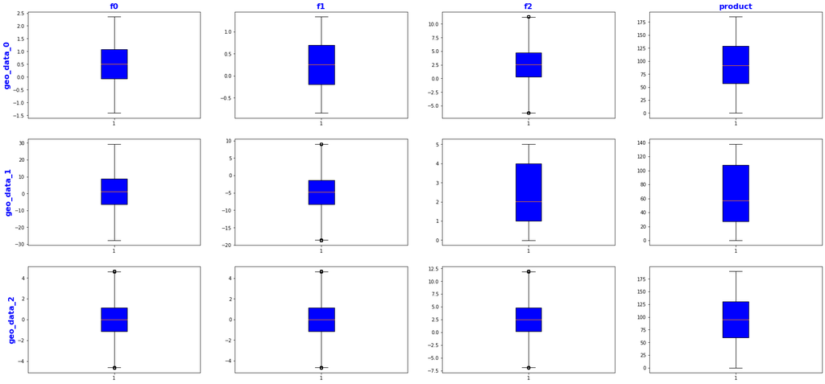

```python
fig,ax = plt.subplots(3,4,figsize = (30,14))

all_data = ['geo_data_0','geo_data_1','geo_data_2']
num_column = geo_data_0.columns[1:]
num_columns = zip(geo_data_0.columns[1:],range(4))
all_data_rows = zip([geo_data_0,geo_data_1,geo_data_2],range(3))

for column in list(itertools.product(all_data_rows,num_columns)):
    ax[column[0][1]][column[1][1]].boxplot(column[0][0][column[1][0]], patch_artist = True, boxprops = dict(facecolor = "blue"))

for row in range(3):
    ax[row][0].set_ylabel(all_data[row], fontsize=16, fontweight="bold", color='blue')

for column in range(4):
    ax[0][column].set_title(num_column[column], fontsize=16, fontweight="bold", color='blue')
```

*Визуализация подтвердила, что выбросы удалены.*

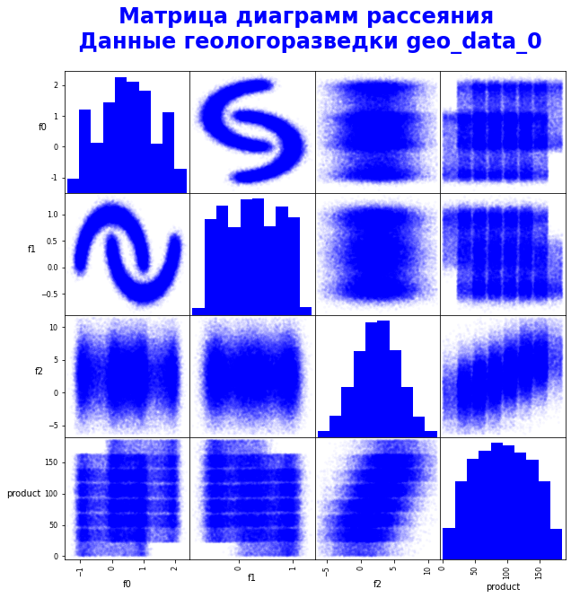

```python
file = geo_data_0
axes = pd.plotting.scatter_matrix(file[file.columns[file.columns !='id']], figsize=(10, 10), color='blue', alpha=0.03, hist_kwds={'bins': 10, 'color':'blue'})
for ax in axes.flatten():
    ax.xaxis.label.set_rotation(0)
    ax.yaxis.label.set_rotation(0)
    ax.yaxis.label.set_ha('right')
plt.suptitle('Матрица диаграмм рассеяния\n Данные геологоразведки geo_data_0\n', fontsize=24, fontweight="bold", color='blue')
plt.show()
```

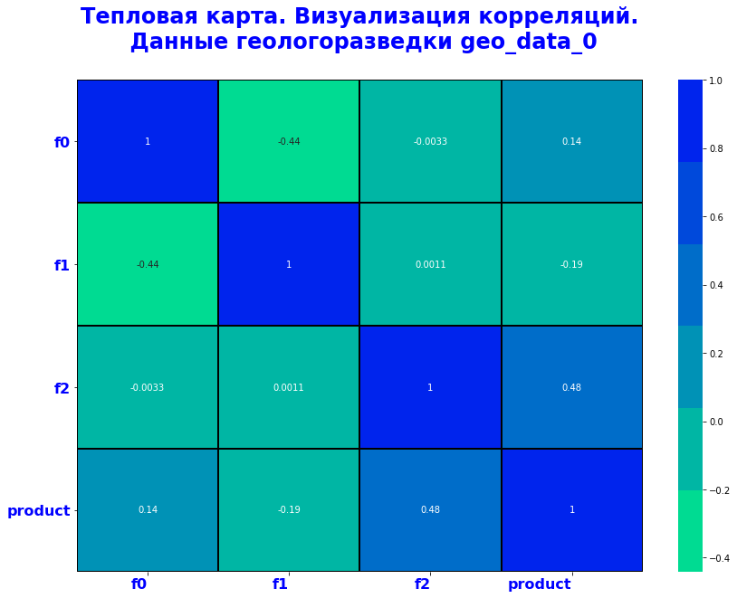

```python
file = geo_data_0
plt.figure(figsize=(14,10))
colormap = sns.color_palette("winter_r")
chart = sns.heatmap(file[file.columns[file.columns != 'id']].corr(), annot=True, cmap=colormap, linewidths=1, linecolor='black')
plt.title('Тепловая карта. Визуализация корреляций.\n Данные геологоразведки geo_data_0\n', fontsize=24, fontweight="bold", color='blue')
chart.set_xticklabels(chart.get_xticklabels(), rotation=0, horizontalalignment='right', fontsize=16, fontweight="bold", color='blue')
chart.set_yticklabels(chart.get_xticklabels(), rotation=0, horizontalalignment='right', fontsize=16, fontweight="bold", color='blue')
plt.show()
```

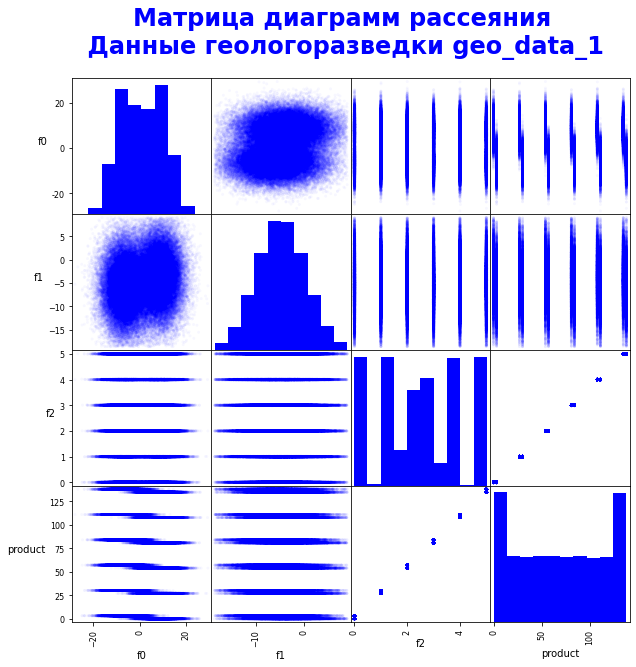

```python
file = geo_data_1
axes = pd.plotting.scatter_matrix(file[file.columns[file.columns !='id']], figsize=(10, 10), color='blue', alpha=0.03, hist_kwds={'bins': 10, 'color':'blue'})
for ax in axes.flatten():
    ax.xaxis.label.set_rotation(0)
    ax.yaxis.label.set_rotation(0)
    ax.yaxis.label.set_ha('right')
plt.suptitle('Матрица диаграмм рассеяния\n Данные геологоразведки geo_data_1\n', fontsize=24, fontweight="bold", color='blue')
plt.show()
```

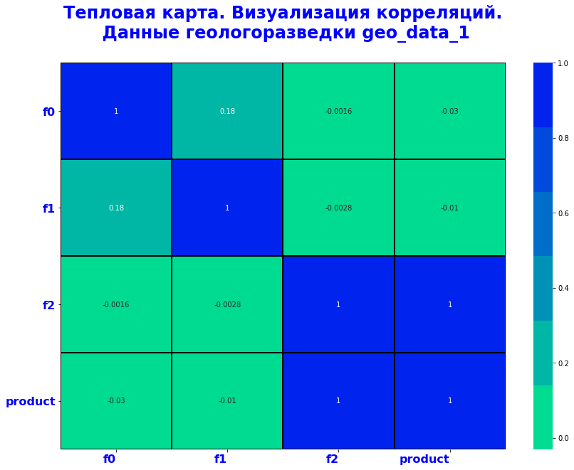

```python
file = geo_data_1
plt.figure(figsize=(14,10))
colormap = sns.color_palette("winter_r")
chart = sns.heatmap(file[file.columns[file.columns != 'id']].corr(), annot=True, cmap=colormap, linewidths=1, linecolor='black')
plt.title('Тепловая карта. Визуализация корреляций.\n Данные геологоразведки geo_data_1\n', fontsize=24, fontweight="bold", color='blue')
chart.set_xticklabels(chart.get_xticklabels(), rotation=0, horizontalalignment='right', fontsize=16, fontweight="bold", color='blue')
chart.set_yticklabels(chart.get_xticklabels(), rotation=0, horizontalalignment='right', fontsize=16, fontweight="bold", color='blue')
plt.show()
```

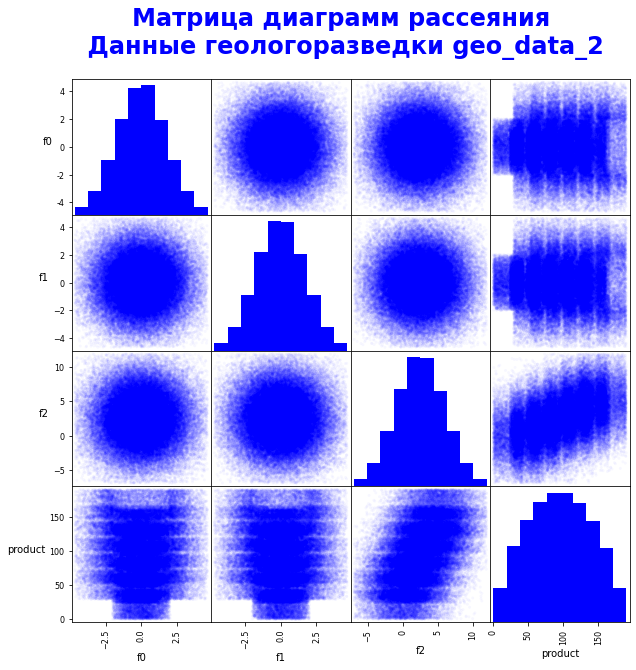

```python
file = geo_data_2
axes = pd.plotting.scatter_matrix(file[file.columns[file.columns !='id']], figsize=(10, 10), color='blue', alpha=0.03, hist_kwds={'bins': 10, 'color':'blue'})
for ax in axes.flatten():
    ax.xaxis.label.set_rotation(0)
    ax.yaxis.label.set_rotation(0)
    ax.yaxis.label.set_ha('right')
plt.suptitle('Матрица диаграмм рассеяния\n Данные геологоразведки geo_data_2\n', fontsize=24, fontweight="bold", color='blue')
plt.show()
```

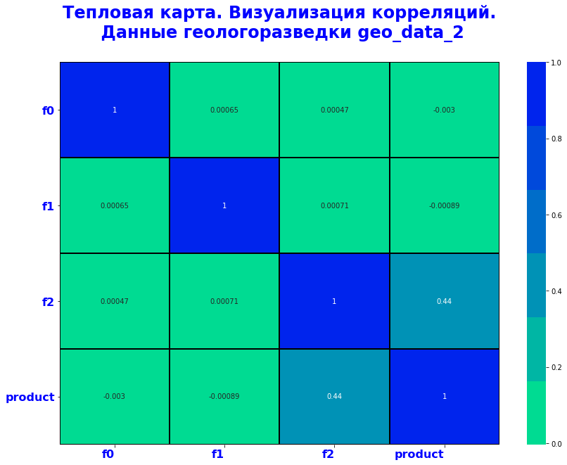

```python
file = geo_data_2
plt.figure(figsize=(14,10))
colormap = sns.color_palette("winter_r")
chart = sns.heatmap(file[file.columns[file.columns != 'id']].corr(), annot=True, cmap=colormap, linewidths=1, linecolor='black')
plt.title('Тепловая карта. Визуализация корреляций.\n Данные геологоразведки geo_data_2\n', fontsize=24, fontweight="bold", color='blue')
chart.set_xticklabels(chart.get_xticklabels(), rotation=0, horizontalalignment='right', fontsize=16, fontweight="bold", color='blue')
chart.set_yticklabels(chart.get_xticklabels(), rotation=0, horizontalalignment='right', fontsize=16, fontweight="bold", color='blue')
plt.show()
```

*Для повышения качества работы моделей машинного обучения воспользуемся способом создания новых признаков.*

```python
geo_data_0['f3'] = geo_data_0['f0'] * geo_data_0['f1']
geo_data_0['f4'] = geo_data_0['f0'] / geo_data_0['f1']
geo_data_0['f5'] = geo_data_0['f0'] * geo_data_0['f0']
geo_data_0['f6'] = geo_data_0['f1'] * geo_data_0['f1']
geo_data_0['f7'] = geo_data_0['f2'] * geo_data_0['f2']
geo_data_0['f8'] = geo_data_0['f0'] + geo_data_0['f1']
```

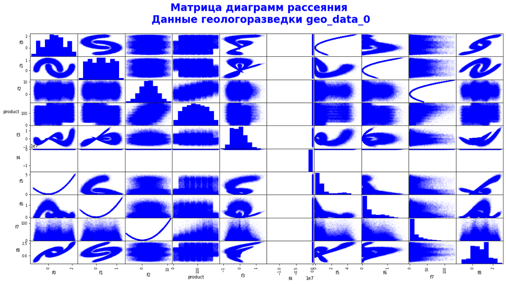

```python
file = geo_data_0
axes = pd.plotting.scatter_matrix(file[file.columns[file.columns !='id']], figsize=(20, 10), color='blue', alpha=0.03, hist_kwds={'bins': 10, 'color':'blue'})
for ax in axes.flatten():
    ax.xaxis.label.set_rotation(0)
    ax.yaxis.label.set_rotation(0)
    ax.yaxis.label.set_ha('right')
plt.suptitle('Матрица диаграмм рассеяния\n Данные геологоразведки geo_data_0\n', fontsize=24, fontweight="bold", color='blue')
plt.show()
```

```python
geo_data_1['f3'] = geo_data_1['f0'] * geo_data_1['f1']
geo_data_1['f4'] = geo_data_1['f0'] / geo_data_1['f1']
geo_data_1['f5'] = geo_data_1['f0'] * geo_data_1['f0']
geo_data_1['f6'] = geo_data_1['f1'] * geo_data_1['f1']
geo_data_1['f7'] = geo_data_1['f2'] * geo_data_1['f2']
geo_data_1['f8'] = geo_data_1['f0'] + geo_data_1['f1']
```

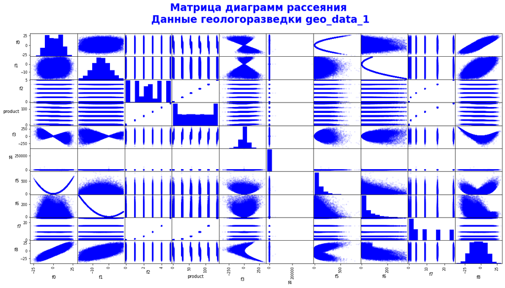

```python
file = geo_data_1
axes = pd.plotting.scatter_matrix(file[file.columns[file.columns !='id']], figsize=(20, 10), color='blue', alpha=0.1, hist_kwds={'bins': 10, 'color':'blue'})
for ax in axes.flatten():
    ax.xaxis.label.set_rotation(0)
    ax.yaxis.label.set_rotation(0)
    ax.yaxis.label.set_ha('right')
plt.suptitle('Матрица диаграмм рассеяния\n Данные геологоразведки geo_data_1\n', fontsize=24, fontweight="bold", color='blue')
plt.show()
```

```python
geo_data_2['f3'] = geo_data_2['f0'] * geo_data_2['f1']
geo_data_2['f4'] = geo_data_2['f0'] / geo_data_2['f1']
geo_data_2['f5'] = geo_data_2['f0'] * geo_data_2['f0']
geo_data_2['f6'] = geo_data_2['f1'] * geo_data_2['f1']
geo_data_2['f7'] = geo_data_2['f2'] * geo_data_2['f2']
geo_data_2['f8'] = geo_data_2['f0'] + geo_data_2['f1']
```

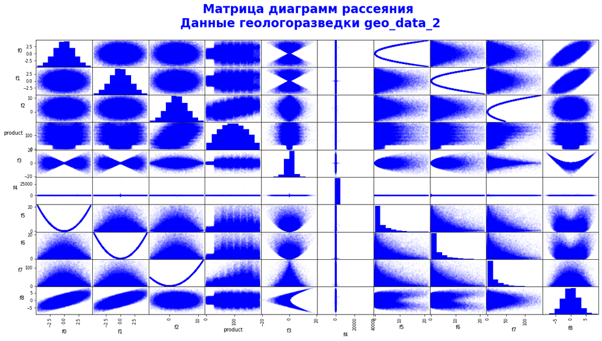

```python
file = geo_data_2
axes = pd.plotting.scatter_matrix(file[file.columns[file.columns !='id']], figsize=(20, 10), color='blue', alpha=0.03, hist_kwds={'bins': 10, 'color':'blue'})
for ax in axes.flatten():
    ax.xaxis.label.set_rotation(0)
    ax.yaxis.label.set_rotation(0)
    ax.yaxis.label.set_ha('right')
plt.suptitle('Матрица диаграмм рассеяния\n Данные геологоразведки geo_data_2\n', fontsize=24, fontweight="bold", color='blue')
plt.show()
```

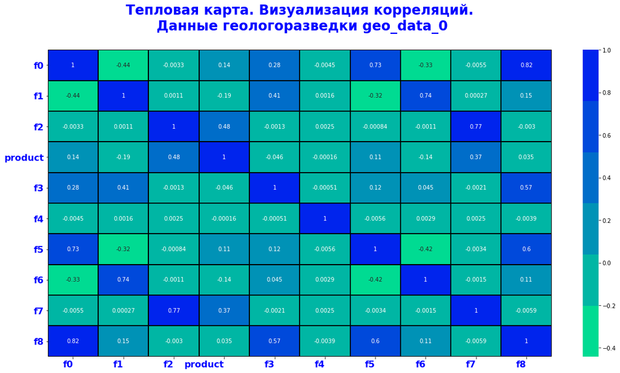

```python
plt.figure(figsize=(20,10))
colormap = sns.color_palette("winter_r")
chart = sns.heatmap(geo_data_0[geo_data_0.columns[geo_data_0.columns != 'id']].corr(), annot=True, cmap=colormap, linewidths=1, linecolor='black')
plt.title('Тепловая карта. Визуализация корреляций.\n Данные геологоразведки geo_data_0\n', fontsize=24, fontweight="bold", color='blue')
chart.set_xticklabels(chart.get_xticklabels(), rotation=0, horizontalalignment='right', fontsize=16, fontweight="bold", color='blue')
chart.set_yticklabels(chart.get_xticklabels(), rotation=0, horizontalalignment='right', fontsize=16, fontweight="bold", color='blue')
plt.show()
```

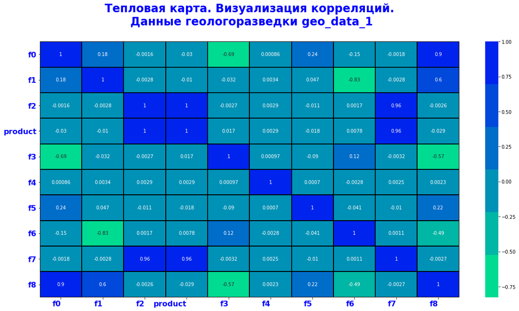

```python
plt.figure(figsize=(20,10))
colormap = sns.color_palette("winter_r")
chart = sns.heatmap(geo_data_1[geo_data_1.columns[geo_data_1.columns != 'id']].corr(), annot=True, cmap=colormap, linewidths=1, linecolor='black')
plt.title('Тепловая карта. Визуализация корреляций.\n Данные геологоразведки geo_data_1\n', fontsize=24, fontweight="bold", color='blue')
chart.set_xticklabels(chart.get_xticklabels(), rotation=0, horizontalalignment='right', fontsize=16, fontweight="bold", color='blue')
chart.set_yticklabels(chart.get_xticklabels(), rotation=0, horizontalalignment='right', fontsize=16, fontweight="bold", color='blue')
plt.show()
```

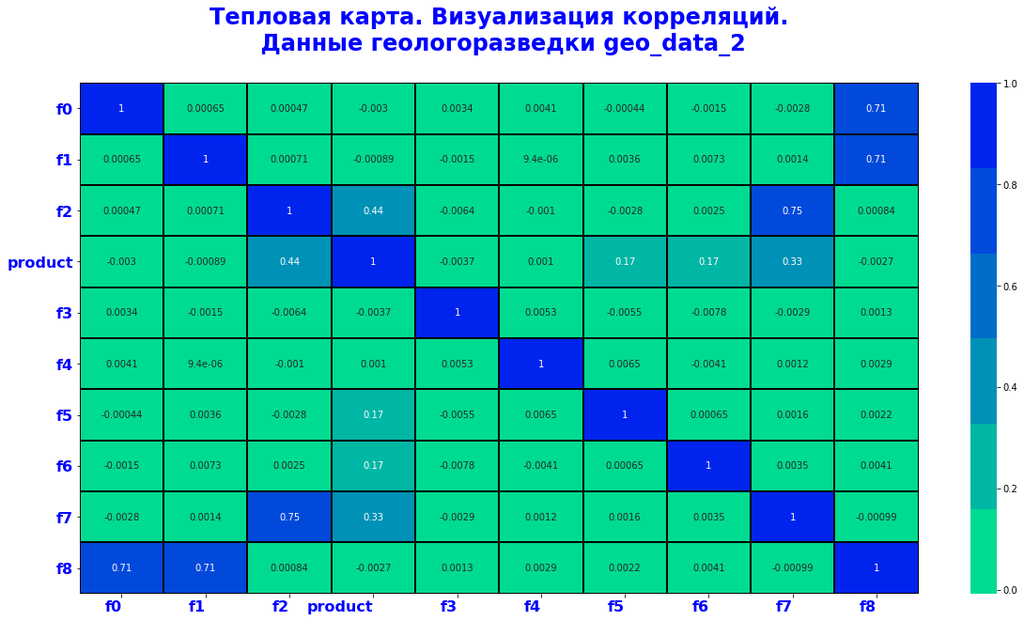

```python
plt.figure(figsize=(20,10))
colormap = sns.color_palette("winter_r")
chart = sns.heatmap(geo_data_2[geo_data_2.columns[geo_data_2.columns != 'id']].corr(), annot=True, cmap=colormap, linewidths=1, linecolor='black')
plt.title('Тепловая карта. Визуализация корреляций.\n Данные геологоразведки geo_data_2\n', fontsize=24, fontweight="bold", color='blue')
chart.set_xticklabels(chart.get_xticklabels(), rotation=0, horizontalalignment='right', fontsize=16, fontweight="bold", color='blue')
chart.set_yticklabels(chart.get_xticklabels(), rotation=0, horizontalalignment='right', fontsize=16, fontweight="bold", color='blue')
plt.show()
```

*На данном этапе исследования были добавлены дополнительные признаки. Провели визуализацию с полным набором добавленных признаков при помощи диаграмм рассеяния и тепловой карты для визуализапции корреляций. Отмечено незначительное количество новых признаков с хорошей корреляцией. Рассчитываем на совокупное использование всех признаков, в том числе и дополненных, для построения более качественной модели.*

## Обучение и проверка модели

```python
data_fact = {'test':{},'pred':{}}

def education(data, columns_education, data_name, name):

    RANDOM_STATE = 42

    X_train, X_test, y_train, y_test = train_test_split(
        data[columns_education],
        data['product'],
        test_size = 0.25,
        random_state = RANDOM_STATE)

    scaler = StandardScaler()
    X_train_scaled = scaler.fit_transform(X_train)
    X_test_scaled = scaler.transform(X_test)

    model_lr = LinearRegression()
    model_lr.fit(X_train_scaled, y_train)

    y_pred = model_lr.predict(X_test_scaled)

    rmse = mean_squared_error(y_test, y_pred, squared = False)

    np_array = np.array(y_pred)
    y_pred = pd.Series(np_array, index = y_test.index)

    data_fact['test'][name] = y_test
    data_fact['pred'][name] = y_pred

    print('\u001b[38;5;19m','Средний запас предсказанного сырья', data_name, round(y_pred.mean(), 2), 'тысяч баррелей','\u001b[0m')
    print('\u001b[38;5;19m','RMSE LinearRegression = ', round(rmse, 2), '\u001b[0m')
    return
```

```python
data = geo_data_0
columns_education = ['f0', 'f1', 'f2', 'f3', 'f4', 'f5', 'f6', 'f7', 'f8']
data_name = 'в 1-ом регионе по данным geo_data_0 ='
name = 'geo_data_0'
```

```python
education(data, columns_education, data_name, name)
```

```
 Средний запас предсказанного сырья в 1-ом регионе по данным geo_data_0 = 92.49 тысяч баррелей
 RMSE LinearRegression =  37.99
```

```python
data = geo_data_1
columns_education = ['f0', 'f1', 'f2', 'f3', 'f4', 'f5', 'f6', 'f7', 'f8']
data_name = 'во 2-ом регионе по данным geo_data_1 ='
name = 'geo_data_1'
```

```python
education(data, columns_education, data_name,  name)
```

```
 Средний запас предсказанного сырья во 2-ом регионе по данным geo_data_1 = 68.61 тысяч баррелей
 RMSE LinearRegression =  0.89
```

```python
data = geo_data_2
columns_education = ['f0', 'f1', 'f2', 'f3', 'f4', 'f5', 'f6', 'f7', 'f8']
data_name = 'в 3-ем регионе по данным geo_data_2 ='
name = 'geo_data_2'
```

```python
education(data, columns_education, data_name, name)
```

```
 Средний запас предсказанного сырья в 3-ем регионе по данным geo_data_2 = 94.66 тысяч баррелей
 RMSE LinearRegression =  38.69
```

*На данном этапе провели обучение и проверку модели линейной регрессии предварительно разделив данные каждого региона на обучающую и валидационную выборки в соотношении 75:25. Привели признаки к единому масштабу для данных каждого региона.*  
*Показано, что максимальный средний запас предсказанного сырья в 3-ем регионе с значением 94.66 тысяч баррелей*  
*В данных 2-го региона `RMSE` стремиться к 0. Это произошло за счёт, фактически, прямой корреляции одного из признаков с целевым, замеченной нами ранее*

## Подготовка к расчёту прибыли

```python
col_points = 500
col_auto = 200
budget = 10000000000
income = 450000
probability = 2.5
volume = budget/income/col_auto

df = pd.DataFrame(columns=['Исследуемое количество точек при бурении', 'Отобранное количество с помощью машинного обучения', 'Бюджет на разработку скважин в регионе,₽',
                           'Доход с одного барреля сырья,₽', 'Доля вероятности убытков,%', 'Объём сырья для безубыточной разработки новой скважины,тысяч баррелей'],  index=range(1, 1))

df['Исследуемое количество точек при бурении'] = df['Исследуемое количество точек при бурении'].astype(int)
df.loc[0] = [col_points, col_auto, budget, income, probability, volume]
df.iloc[:,0:4] = df.iloc[:,0:4].astype(int)

display(df.style.background_gradient(cmap='Blues', axis=0))
```

|  | Исследуемое количество точек при бурении | Отобранное количество с помощью машинного обучения | Бюджет на разработку скважин в регионе,₽ | Доход с одного барреля сырья,₽ | Доля вероятности убытков,% | Объём сырья для безубыточной разработки новой скважины,тысяч баррелей |
| --- | --- | --- | --- | --- | --- | --- |
| 0 | 500 | 200 | 10000000000 | 450000 | 2.500000 | 111.111111 |

```python
print('\u001b[38;5;19m','Объём сырья для безубыточной разработки новой скважины: ', round(volume, 2), 'тысяч баррелей','\u001b[0m')
```

```
 Объём сырья для безубыточной разработки новой скважины:  111.11 тысяч баррелей
```

```python
print('\u001b[38;5;19m','Средний объем запасов скважины в 1-ом регионе по данным geo_data_0:  ', round(geo_data_0['product'].mean(), 2), 'тысяч баррелей','\u001b[0m')
print('\u001b[38;5;19m','Средний объем запасов скважины во 2-ом регионе по данным geo_data_1:  ', round(geo_data_1['product'].mean(), 2), 'тысяч баррелей','\u001b[0m')
print('\u001b[38;5;19m','Средний объем запасов скважины в 3-ем регионе по данным geo_data_2:  ', round(geo_data_2['product'].mean(), 2), 'тысяч баррелей','\u001b[0m')
```

```
 Средний объем запасов скважины в 1-ом регионе по данным geo_data_0:   92.5 тысяч баррелей
 Средний объем запасов скважины во 2-ом регионе по данным geo_data_1:   68.81 тысяч баррелей
 Средний объем запасов скважины в 3-ем регионе по данным geo_data_2:   94.79 тысяч баррелей
```

*Объём сырья для безубыточной разработки новой скважины равен 111.11 тысяч баррелей. Средний объем запасов скважин во всех регионах меньше этого значения.*  
*Во 2-ом регионе наша модель очень хорошо прогнозирует запасы скважин, хотя средние запасы меньше необходимых почти в 1,5 раза и составляют 68.81 тысяч баррелей.*

## Расчёт прибыли и рисков

```python
def profit(target, predictions):
    sort_predictions = predictions.sort_values(ascending=False)
    sort_target = target[sort_predictions.index][:col_auto]
    sum_barrel = sort_target.sum()
    return ((sum_barrel * income) - budget)
```

```python
print('\u001b[38;5;19m','Прибыль по выбранным скважинам в 1-ом регионе по данным geo_data_0:  ', round(profit(data_fact['test']['geo_data_0'], data_fact['pred']['geo_data_0']).astype(int), 0), ' рублей','\u001b[0m')
print('\u001b[38;5;19m','Прибыль по выбранным скважинам во 2-ом регионе по данным geo_data_1:  ', round(profit(data_fact['test']['geo_data_1'], data_fact['pred']['geo_data_1']).astype(int), 0), ' рублей','\u001b[0m')
print('\u001b[38;5;19m','Прибыль по выбранным скважинам в 3-ем регионе по данным geo_data_2:  ', round(profit(data_fact['test']['geo_data_1'], data_fact['pred']['geo_data_1']).astype(int), 0), ' рублей','\u001b[0m')
```

[output not shown]

```python
def bootsrtap(target, predictions):
    state = np.random.RandomState(12345)

    profit_sample = []
    for i in range(1000):
        sample_target = target.sample(replace = True, random_state = state , n = 500)
        sample_predictions = predictions[sample_target.index]

        profit_sample.append(profit(sample_target, sample_predictions))

    profit_sample = pd.Series(profit_sample)
    return profit_sample
```

```python
raspred_0 = bootsrtap(data_fact['test']['geo_data_0'], data_fact['pred']['geo_data_0'])
raspred_1 = bootsrtap(data_fact['test']['geo_data_1'], data_fact['pred']['geo_data_1'])
raspred_2 = bootsrtap(data_fact['test']['geo_data_2'], data_fact['pred']['geo_data_2'])
```

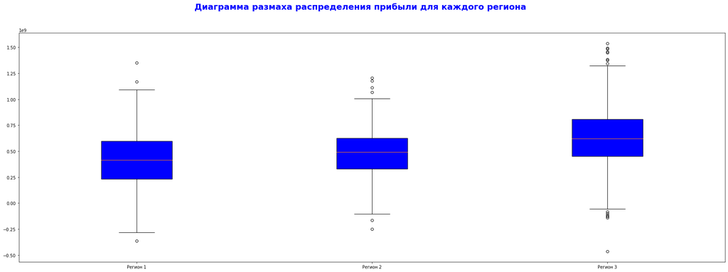

```python
fig, ax = plt.subplots(figsize=(30, 10))
box_plot_data=[raspred_0, raspred_1, raspred_2]

plt.boxplot(box_plot_data, patch_artist=True, boxprops = dict(facecolor = "blue"), labels = ['Регион 1','Регион 2','Регион 3'])
plt.suptitle(f'Диаграмма размаха распределения прибыли для каждого региона', fontsize=20, fontweight="bold", color='blue')
plt.show()
```

```python
print('\u001b[38;5;19m','Cредняя прибыль в 1-ом регионе по данным geo_data_0:  ', round(raspred_0.mean(),0).astype(int), 'рублей','\u001b[0m')
print('\u001b[38;5;19m','95%-й доверительный интервал в 1-ом регионе по данным geo_data_0: от ', round(raspred_0.quantile(0.025),0).astype(int), 'до',  round(raspred_0.quantile(0.975),0).astype(int), 'рублей','\u001b[0m')
print('\u001b[38;5;19m','Риск убытков в 1-ом регионе по данным geo_data_0:  ', round(raspred_0.apply(lambda x: x < 0).sum()/len(raspred_0)*100,3), '%','\u001b[0m')
```

```
 Cредняя прибыль в 1-ом регионе по данным geo_data_0:   407375086 рублей
 95%-й доверительный интервал в 1-ом регионе по данным geo_data_0: от  -119537332 до 887439844 рублей
 Риск убытков в 1-ом регионе по данным geo_data_0:   7.2 %
```

```python
print('\u001b[38;5;19m','Cредняя прибыль во 2-ом регионе по данным geo_data_1:  ', round(raspred_1.mean(),0).astype(int), 'рублей','\u001b[0m')
print('\u001b[38;5;19m','95%-й доверительный интервал во 2-ом регионе по данным geo_data_1: от ', round(raspred_1.quantile(0.025),0).astype(int), 'до',  round(raspred_1.quantile(0.975),0).astype(int), 'рублей','\u001b[0m')
print('\u001b[38;5;19m','Риск убытков во 2-ом регионе по данным geo_data_0:  ', round(raspred_1.apply(lambda x: x < 0).sum()/len(raspred_1)*100,3), '%','\u001b[0m')
```

```
 Cредняя прибыль во 2-ом регионе по данным geo_data_1:   480051816 рублей
 95%-й доверительный интервал во 2-ом регионе по данным geo_data_1: от  23237208 до 896627050 рублей
 Риск убытков во 2-ом регионе по данным geo_data_0:   1.8 %
```

```python
print('\u001b[38;5;19m','Cредняя прибыль в 3-ем регионе по данным geo_data_2:  ', round(raspred_2.mean(),0).astype(int), 'рублей','\u001b[0m')
print('\u001b[38;5;19m','95%-й доверительный интервал в 3-ем регионе по данным geo_data_2: от ', round(raspred_2.quantile(0.025),0).astype(int), 'до',  round(raspred_2.quantile(0.975),0).astype(int), 'рублей','\u001b[0m')
print('\u001b[38;5;19m','Риск убытков в 3-ем регионе по данным geo_data_2:  ', round(raspred_2.apply(lambda x: x < 0).sum()/len(raspred_2)*100,3), '%','\u001b[0m')
```

```
 Cредняя прибыль в 3-ем регионе по данным geo_data_2:   624004442 рублей
 95%-й доверительный интервал в 3-ем регионе по данным geo_data_2: от  98353812 до 1140463074 рублей
 Риск убытков в 3-ем регионе по данным geo_data_2:   1.0 %
```

## Выводы:

*Вывод по предлагаемому региону:*

*По результатам проведенного анализа сделан следующий вывод, что прибыль в 3-ем регионе по данным geo_data_2 выше остальных и риск убытов минимален. И на основе анализа, этот регион предлагается для разработки скважин.*